```python
!pip install scikit-learn pandas seaborn scipy numpy gensim nltk stopwords
```

# LSA

```python
#import modules
import os.path
from gensim import corpora
from gensim.models import LsiModel
from nltk.tokenize import RegexpTokenizer
from nltk.corpus import stopwords
from nltk.stem.porter import PorterStemmer
import nltk
nltk.download('stopwords')
from gensim.models.coherencemodel import CoherenceModel
import matplotlib.pyplot as plt
```

```python
import numpy as np
import pandas as pd
import matplotlib.pyplot as plt
import seaborn as sns
from sklearn import decomposition
from sklearn.preprocessing import StandardScaler
from sklearn.cluster import KMeans
import scipy.cluster.hierarchy as sch
from sklearn.mixture import GaussianMixture
from sklearn.metrics import silhouette_samples, silhouette_score, davies_bouldin_score
from sklearn.cluster import DBSCAN
import matplotlib.cm as cm
```

## Инициализация датасета

https://www.kaggle.com/datasets/parulpandey/palmer-archipelago-antarctica-penguin-data/data

Данные о пингвинах архипелага Палмера (Антарктида):

- bill_length_mm: число, обозначающее длину клюва (миллиметры)
- bill_depth_mm: число, обозначающее ширину клюва (миллиметры)
- flipper_length_mm: целое число, обозначающее длину ласта (миллиметры)
- body_mass_g: целое число, обозначающее массу тела (граммы)

```python
df = sns.load_dataset("penguins")
print(len(df))
```

```
344
```

Видим, что всего в датасете 344 индивида. Проверим данные на пропуски:

```python
print(df.isna().sum())
```

```
species               0
island                0
bill_length_mm        2
bill_depth_mm         2
flipper_length_mm     2
body_mass_g           2
sex                  11
dtype: int64
```

Видим, что в данных они присутствуют, можем их удалить:

```python
df = df.dropna()
print(len(df))
print(df.head())

print(len(df.where(df.species == "Chinstrap").dropna()))
```

```
333
  species     island  bill_length_mm  bill_depth_mm  flipper_length_mm  \
0  Adelie  Torgersen            39.1           18.7              181.0
1  Adelie  Torgersen            39.5           17.4              186.0
2  Adelie  Torgersen            40.3           18.0              195.0
4  Adelie  Torgersen            36.7           19.3              193.0
5  Adelie  Torgersen            39.3           20.6              190.0

   body_mass_g     sex
0       3750.0    Male
1       3800.0  Female
2       3250.0  Female
4       3450.0  Female
5       3650.0    Male
68
```

Выведем априорные вероятности по классам:

```python
pDf = {'Adelie': [len(df.where(df.species == "Adelie").dropna()) / len(df)], 'Chinstrap': [len(df.where(df.species == "Chinstrap").dropna())/ len(df)], 'Gentoo': [len(df.where(df.species == "Gentoo").dropna())/ len(df)]}

print(pDf)
```

```
{'Adelie': [0.43843843843843844], 'Chinstrap': [0.2042042042042042], 'Gentoo': [0.35735735735735735]}
```

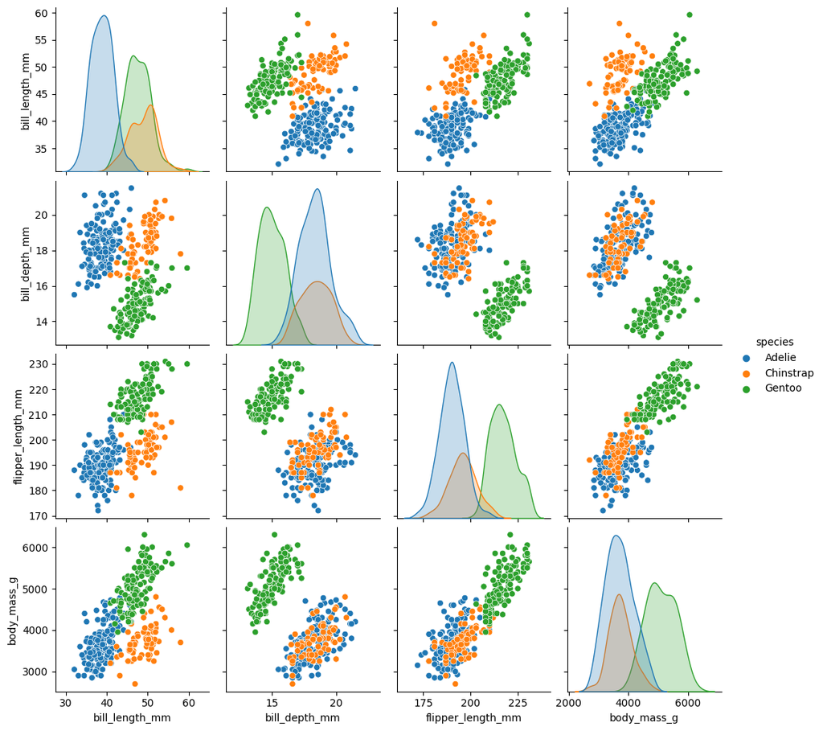

```python
sns.pairplot(df, hue="species")
```

# Feature selection / extraction

## АГК

Чтобы улучшить разделимость применим анализ главных компонент. Для начала удалим строковые признаки:

```python
dfCut = df.copy()
dfCut = dfCut.drop("species", axis = 1)
dfCut = dfCut.drop("island", axis = 1)
dfCut = dfCut.drop("sex", axis = 1)
dfCut.head()
```

|  | bill_length_mm | bill_depth_mm | flipper_length_mm | body_mass_g |
| --- | --- | --- | --- | --- |
| 0 | 39.1 | 18.7 | 181.0 | 3750.0 |
| 1 | 39.5 | 17.4 | 186.0 | 3800.0 |
| 2 | 40.3 | 18.0 | 195.0 | 3250.0 |
| 4 | 36.7 | 19.3 | 193.0 | 3450.0 |
| 5 | 39.3 | 20.6 | 190.0 | 3650.0 |

```python
pca = decomposition.PCA(n_components=3)
print(pca)
dfCutPCA = StandardScaler().fit_transform(dfCut)
pc = pca.fit_transform(dfCutPCA)
print(
    "explained variance ratio (first 3 components): %s"
    % str(pca.explained_variance_ratio_)
)

print(pca.components_)
```

```
PCA(n_components=3)
explained variance ratio (first 3 components): [0.68633893 0.19452929 0.09216063]
[[ 0.45375317 -0.39904723  0.576825    0.54967471]
 [ 0.6001949   0.79616951  0.00578817  0.07646366]
 [ 0.64249509 -0.42580043 -0.23609516 -0.59173738]]
```

Число компонент было выбрано = 3, были построены графики на для 2 компонент, но попарные графики PC1/PC3 и PC2/PC3 дают лучшую разделимость для кластеров Adelie/Chinstrap

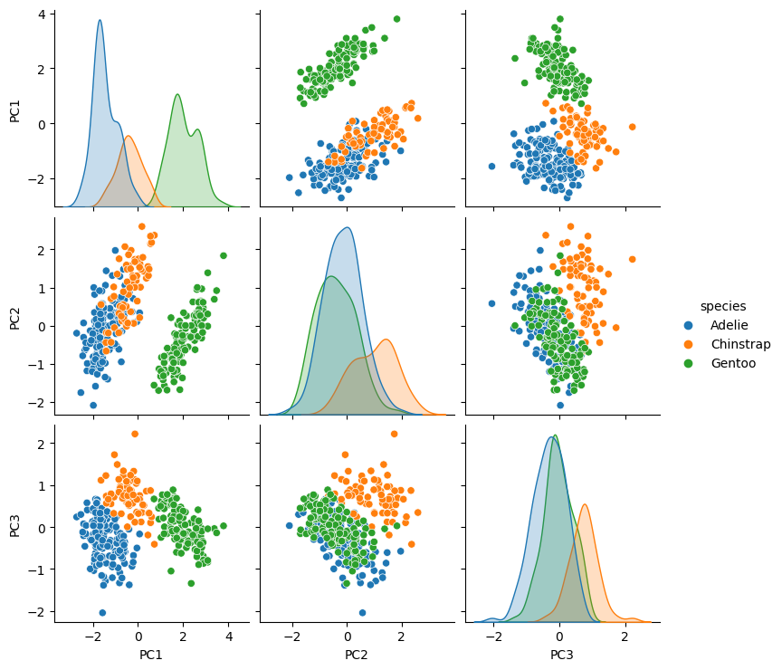

```python
pcaFeatures = {'PC1': pc[:,0], 'PC2': pc[:,1], 'PC3': pc[:,2], 'species': df.species}
dfPca = pd.DataFrame(data=pcaFeatures)
sns.pairplot(dfPca, hue="species")
dfPcaCut = dfPca.drop("species", axis = 1)
```

# EM-алгоритм

Попробуем подобрать число кластеров, перебирая модели и оценивая gm.score (gm.score - обратная сумма квадратов расстояний между центрами кластеров):

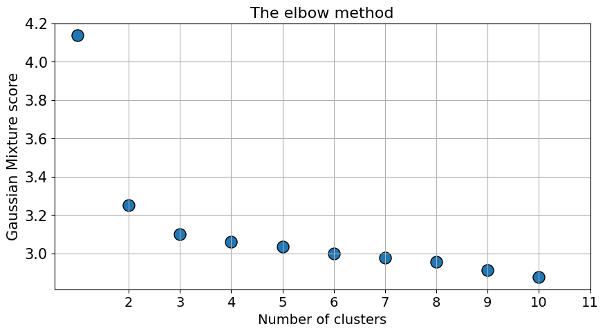

```python
gm_scores = []
for i in range(1,11):
    gm = GaussianMixture(n_components=i, random_state=0).fit(dfPcaCut)
    preds = gm.predict(dfPcaCut)
    gm_scores.append(-gm.score(dfPcaCut))
plt.figure(figsize=(10,5))
plt.title("The elbow method",fontsize=16)
plt.scatter(x=[i for i in range(1,11)],y=gm_scores,s=150,edgecolor='k')
plt.grid(True)
plt.xlabel("Number of clusters",fontsize=14)
plt.ylabel("Gaussian Mixture score",fontsize=15)
plt.xticks([i for i in range(2,12)],fontsize=14)
plt.yticks(fontsize=15)
plt.show()
```

Посчитаем $BIC$ для каждого типа ковариационнной матрицы:

- ‘full’: каждый компонент имеет свою собственную общую ковариационную матрицу.
- ‘tied’: все компоненты имеют одну и ту же общую ковариационную матрицу.
- ‘diag’: каждый компонент имеет свою собственную диагональную ковариационную матрицу.

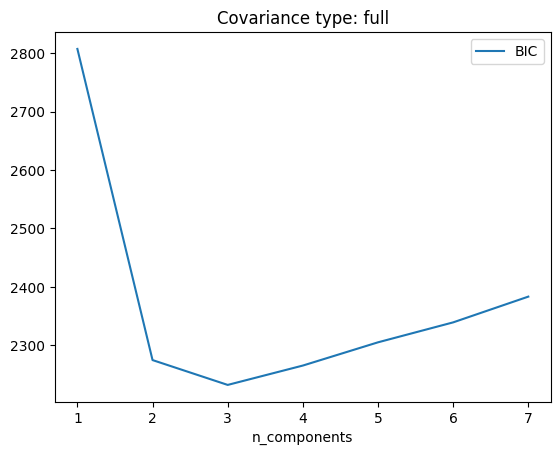

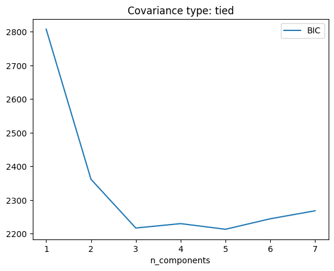

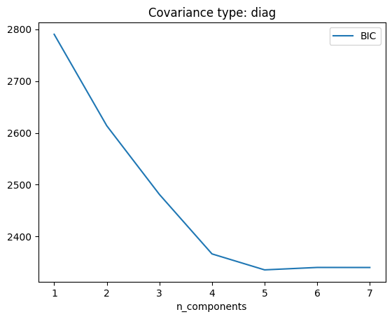

```python
n_components = np.arange(1, 8)

for cov_type in ['full', 'tied', 'diag']:

    models = [GaussianMixture(n, random_state=0, covariance_type = cov_type).fit(dfPcaCut) for n in n_components]

    plt.plot(n_components, [m.bic(dfPcaCut) for m in models], label='BIC')
    plt.legend(loc='best')
    plt.xlabel('n_components')
    plt.title(f"Covariance type: {cov_type}")
    plt.show()
```

```
For n_clusters = 3 The average silhouette_score is : 0.478
For n_clusters = 4 The average silhouette_score is : 0.428
For n_clusters = 5 The average silhouette_score is : 0.403
For n_clusters = 6 The average silhouette_score is : 0.386
```

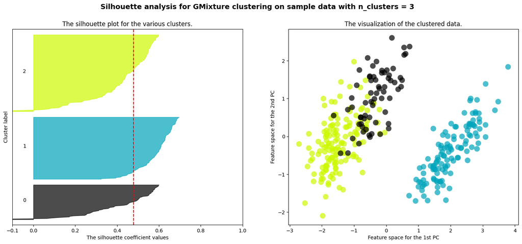

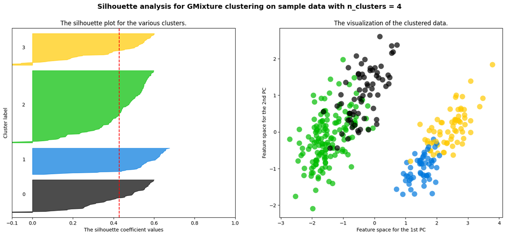

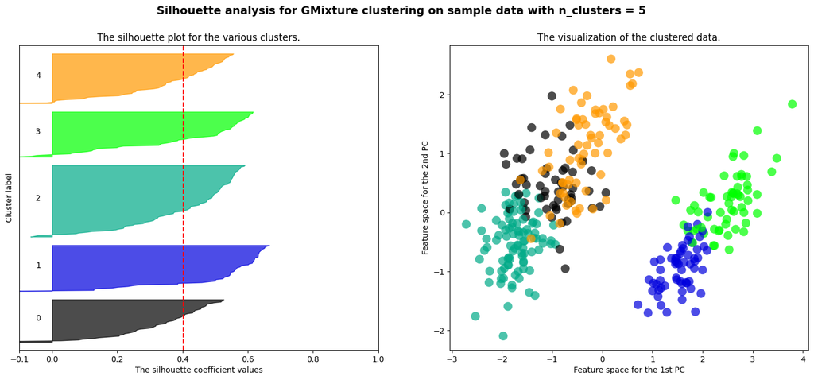

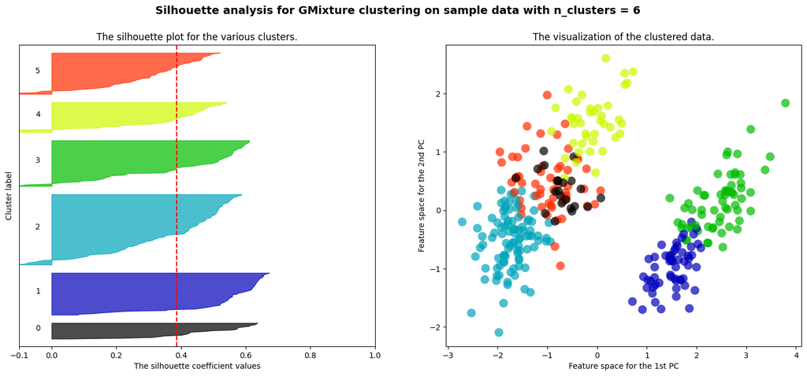

```python
# https://scikit-learn.org/stable/auto_examples/cluster/plot_kmeans_silhouette_analysis.html
X, y = dfPcaCut, dfPca.species
range_n_clusters = [3,4, 5, 6]
cov_type = "full"

for n_clusters in range_n_clusters:
    fig, (ax1, ax2) = plt.subplots(1, 2)
    fig.set_size_inches(18, 7)
    ax1.set_xlim([-0.1, 1])
    ax1.set_ylim([0, len(X) + (n_clusters + 1) * 10])
    clusterer = GaussianMixture(n_components=n_clusters, random_state=0, covariance_type = cov_type)
    cluster_labels = clusterer.fit_predict(X)
    silhouette_avg = silhouette_score(X, cluster_labels)
    print(
        "For n_clusters =",
        n_clusters,
        "The average silhouette_score is : %0.3f"
        % silhouette_avg,
    )
    sample_silhouette_values = silhouette_samples(X, cluster_labels)
    y_lower = 10
    for i in range(n_clusters):
        ith_cluster_silhouette_values = sample_silhouette_values[cluster_labels == i]
        ith_cluster_silhouette_values.sort()
        size_cluster_i = ith_cluster_silhouette_values.shape[0]
        y_upper = y_lower + size_cluster_i
        color = cm.nipy_spectral(float(i) / n_clusters)
        ax1.fill_betweenx(
            np.arange(y_lower, y_upper),
            0,
            ith_cluster_silhouette_values,
            facecolor=color,
            edgecolor=color,
            alpha=0.7,
        )
        ax1.text(-0.05, y_lower + 0.5 * size_cluster_i, str(i))
        y_lower = y_upper + 10
    ax1.set_title("The silhouette plot for the various clusters.")
    ax1.set_xlabel("The silhouette coefficient values")
    ax1.set_ylabel("Cluster label")
    ax1.axvline(x=silhouette_avg, color="red", linestyle="--")
    ax1.set_yticks([])
    ax1.set_xticks([-0.1, 0, 0.2, 0.4, 0.6, 0.8, 1])
    colors = cm.nipy_spectral(cluster_labels.astype(float) / n_clusters)
    ax2.scatter(
        pc[:, 0], pc[:, 1], marker=".", s=500, lw=0, alpha=0.7, c=colors, edgecolor="k"
    )
    ax2.set_title("The visualization of the clustered data.")
    ax2.set_xlabel("Feature space for the 1st PC")
    ax2.set_ylabel("Feature space for the 2nd PC")
    plt.suptitle(
        "Silhouette analysis for GMixture clustering on sample data with n_clusters = %d"
        % n_clusters,
        fontsize=14,
        fontweight="bold",
    )
plt.show()
```

Здесь надо обращать внимание на коэффициент силуэта и его близость к 1 (чем ближе, тем более выражено расстояние между кластерами), а также на размеры силуэтов на левом графике. По такому алгоритму рекомендуется брать $n = 3$.

Зная, что у нас внутри кластеров лежат 3 группы построим матрицу предсказания для полной матрицы и $n = 3$;

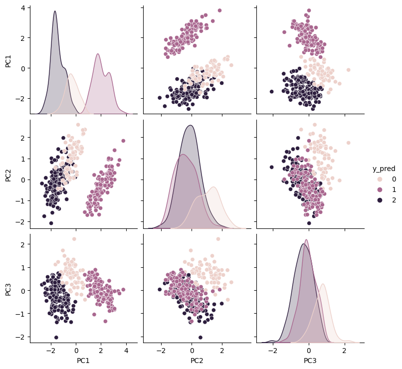

```python
gmixture = GaussianMixture(n_components=3, covariance_type="full", random_state=0).fit(dfPcaCut)
y_pred = gmixture.fit_predict(dfPcaCut)
gmixtureDf = dfPca.copy()
gmixtureDf['y_pred'] = y_pred
sns.pairplot(gmixtureDf, hue="y_pred")
```

Построим матрицу предсказаний

```python
# 0 - Chinstrap
# 1 - Gentoo
# 2 - Adelie

gmixtureDf['species'] = dfPca['species']

m33 = len(gmixtureDf.where((gmixtureDf.y_pred == 2) & (gmixtureDf.species == "Adelie")).dropna()) # TRUE
m32 = len(gmixtureDf.where((gmixtureDf.y_pred == 2) & (gmixtureDf.species == "Gentoo")).dropna())
m31 = len(gmixtureDf.where((gmixtureDf.y_pred == 2) & (gmixtureDf.species == "Chinstrap")).dropna())

m22 = len(gmixtureDf.where((gmixtureDf.y_pred == 1) & (gmixtureDf.species == "Gentoo")).dropna()) # TRUE
m23 = len(gmixtureDf.where((gmixtureDf.y_pred == 1) & (gmixtureDf.species == "Adelie")).dropna())
m21 = len(gmixtureDf.where((gmixtureDf.y_pred == 1) & (gmixtureDf.species == "Chinstrap")).dropna())


m11 = len(gmixtureDf.where((gmixtureDf.y_pred == 0) & (gmixtureDf.species == "Chinstrap")).dropna()) # TRUE
m12 = len(gmixtureDf.where((gmixtureDf.y_pred == 0) & (gmixtureDf.species == "Gentoo")).dropna())
m13 = len(gmixtureDf.where((gmixtureDf.y_pred == 0) & (gmixtureDf.species == "Adelie")).dropna())

predictMatrix = {'Chinstrap': [m11, m21, m31], 'Gentoo': [m12, m22, m32], 'Adelie': [m13, m23, m33]}
dfPredictMatrix = pd.DataFrame(data=predictMatrix)
print(dfPredictMatrix)
```

```
   Chinstrap  Gentoo  Adelie
0         65       0       2
1          0     119       0
2          3       0     144
```

# K-means

Оценка числа кластеров (kmeans.score - обратная сумма квадратов расстояний между центрами кластеров):

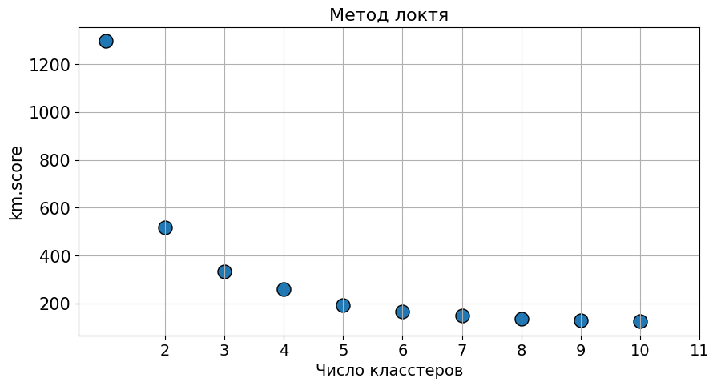

```python
km_scores= []
for i in range(1,11):
    km = KMeans(n_clusters=i, random_state=0, n_init=1).fit(dfPcaCut)
    preds = km.predict(dfPcaCut)
    km_scores.append(-km.score(dfPcaCut))
plt.figure(figsize=(10,5))
plt.title("Метод локтя",fontsize=16)
plt.scatter(x=[i for i in range(1,11)],y=km_scores,s=150,edgecolor='k')
plt.grid(True)
plt.xlabel("Число класстеров",fontsize=14)
plt.ylabel("km.score",fontsize=15)
plt.xticks([i for i in range(2,12)],fontsize=14)
plt.yticks(fontsize=15)
plt.show()
```

Предлагается брать число кластеров $n = 3$. Посчитаем ошибки:

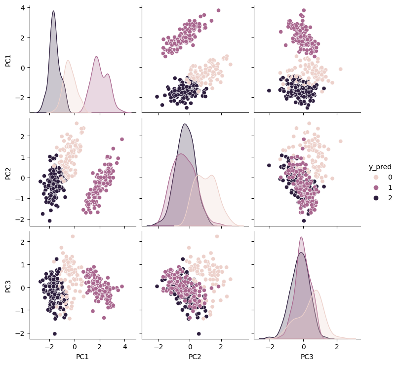

```python
kmeans = KMeans(n_clusters=3, random_state=0).fit(dfPcaCut)
y_pred = kmeans.fit_predict(dfPcaCut)
kmeansDf = dfPca.copy()
kmeansDf['y_pred'] = y_pred
sns.pairplot(kmeansDf, hue="y_pred")
```

Матрица предсказаний

```python
# 0 - Chinstrap
# 1 - Gentoo
# 2 - Adelie

kmeansDf['species'] = dfPca['species']

m33 = len(kmeansDf.where((kmeansDf.y_pred == 2) & (kmeansDf.species == "Adelie")).dropna())
m32 = len(kmeansDf.where((kmeansDf.y_pred == 2) & (kmeansDf.species == "Gentoo")).dropna())
m31 = len(kmeansDf.where((kmeansDf.y_pred == 2) & (kmeansDf.species == "Chinstrap")).dropna())

m22 = len(kmeansDf.where((kmeansDf.y_pred == 1) & (kmeansDf.species == "Gentoo")).dropna())
m23 = len(kmeansDf.where((kmeansDf.y_pred == 1) & (kmeansDf.species == "Adelie")).dropna())
m21 = len(kmeansDf.where((kmeansDf.y_pred == 1) & (kmeansDf.species == "Chinstrap")).dropna())


m11 = len(kmeansDf.where((kmeansDf.y_pred == 0) & (kmeansDf.species == "Chinstrap")).dropna())
m12 = len(kmeansDf.where((kmeansDf.y_pred == 0) & (kmeansDf.species == "Gentoo")).dropna())
m13 = len(kmeansDf.where((kmeansDf.y_pred == 0) & (kmeansDf.species == "Adelie")).dropna())

predictMatrix = {'Chinstrap': [m11, m21, m31], 'Gentoo': [m12, m22, m32], 'Adelie': [m13, m23, m33]}
dfPredictMatrix = pd.DataFrame(data=predictMatrix)
print(dfPredictMatrix)
```

```
   Chinstrap  Gentoo  Adelie
0         63       0      22
1          0     119       0
2          5       0     124
```

# Иерархическая кластеризация

Путем перебора расстояния *method* кластеры близкие по размеру оригинальным группам получились при методе **ward** (сводит к минимуму дисперсию объединяемых кластеров)

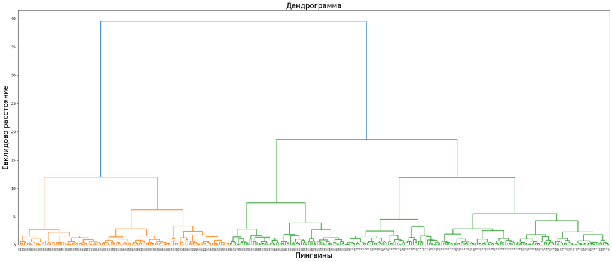

```python
import scipy.cluster.hierarchy as sch
fig = plt.figure(figsize = (30,12))
fig.add_subplot()
dendrogram = sch.dendrogram(sch.linkage(dfPcaCut, method = 'ward'))
plt.title('Дендрограмма', fontsize = 20)
plt.xlabel('Пингвины', fontsize = 20)
plt.ylabel('Евклидово расстояние', fontsize = 20)
plt.show()
```

Построим модель:

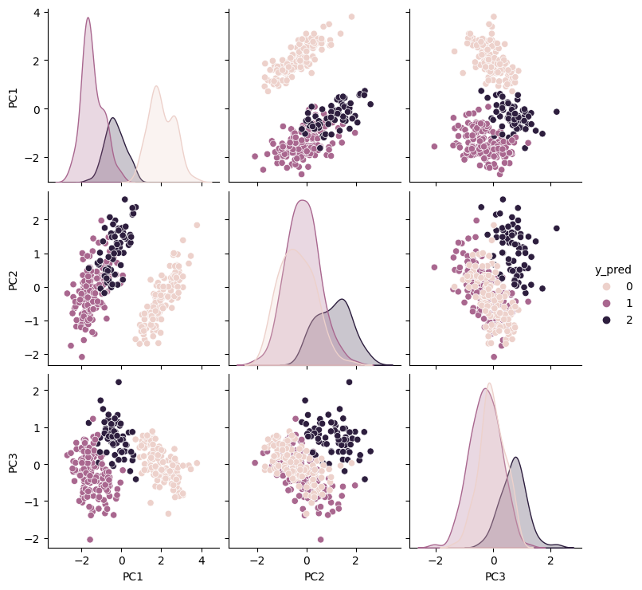

```python
from sklearn.cluster import AgglomerativeClustering
model = AgglomerativeClustering(n_clusters = 3, affinity = 'euclidean', linkage = 'ward')
y_pred = model.fit_predict(dfPcaCut)
hieDf = dfPcaCut.copy()
hieDf['y_pred'] = y_pred
sns.pairplot(hieDf, hue="y_pred")
```

```python
# 2 - Chinstrap
# 1 - Adelie
# 0 - Gentoo

hieDf['species'] = df['species']

m33 = len(hieDf.where((hieDf.y_pred == 2) & (hieDf.species == "Chinstrap")).dropna())
m32 = len(hieDf.where((hieDf.y_pred == 2) & (hieDf.species == "Adelie")).dropna())
m31 = len(hieDf.where((hieDf.y_pred == 2) & (hieDf.species == "Gentoo")).dropna())

m22 = len(hieDf.where((hieDf.y_pred == 1) & (hieDf.species == "Adelie")).dropna())
m23 = len(hieDf.where((hieDf.y_pred == 1) & (hieDf.species == "Chinstrap")).dropna())
m21 = len(hieDf.where((hieDf.y_pred == 1) & (hieDf.species == "Gentoo")).dropna())


m11 = len(hieDf.where((hieDf.y_pred == 0) & (hieDf.species == "Gentoo")).dropna())
m12 = len(hieDf.where((hieDf.y_pred == 0) & (hieDf.species == "Adelie")).dropna())
m13 = len(hieDf.where((hieDf.y_pred == 0) & (hieDf.species == "Chinstrap")).dropna())

predictMatrix = {'Gentoo': [m11, m21, m31], 'Adelie': [m12, m22, m32], 'Chinstrap': [m13, m23, m33]}
dfPredictMatrix = pd.DataFrame(data=predictMatrix)
print(dfPredictMatrix)
```

```
   Gentoo  Adelie  Chinstrap
0     119       0          0
1       0     144          5
2       0       2         63
```

# DBSCAN

Воспользуемся методом DBSCAN() из пакета sklearn.cluster.

### На практике

На практике не получилось сделать такую комбинацию значений, чтобы образовалось 3 кластера, размерами сопоставимыми с оригинальным разделением на группы: наилучшие параметры были при eps=77, min_samples = 30 - для них получились 2 больших кластера. При уменьшении min_samples до 20 кластеров так и остается 2, при уменьшении до 10, получается большое число кластеров, которое в комбинации с eps не получается снизить до адекватного количества ($n \in [3 \dots 6]$).

Если снижать eps до рекомендуемого, все наблюдения уходят в класс -1 (шум).

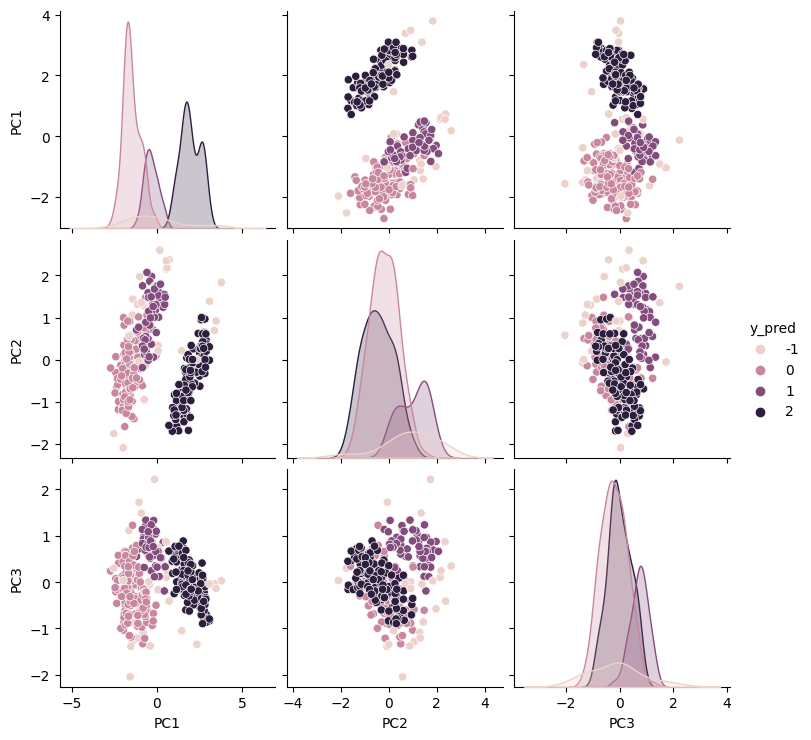

```python
db = DBSCAN(eps=0.5, min_samples = 5).fit(dfPcaCut)
y_pred = db.labels_
dbscanDf = dfPcaCut.copy()
dbscanDf['y_pred'] = y_pred
sns.pairplot(dbscanDf, hue="y_pred")
```

Для такого разделения адекватно посчитать TPR и accuracy не представляется возможным, поэтому в качестве датасета укажем в dbscan не оригинальный датасет, а индивидов в плоскости первых 3 компонент.

```python
# 0 - Adelie
# 1 - Chinstrap
# 2 - Gentoo

dbscanDf['species'] = dfPCA['species']

m33 = len(dbscanDf.where((dbscanDf.y_pred == 2) & (dbscanDf.species == "Gentoo")).dropna())
m32 = len(dbscanDf.where((dbscanDf.y_pred == 2) & (dbscanDf.species == "Chinstrap")).dropna())
m31 = len(dbscanDf.where((dbscanDf.y_pred == 2) & (dbscanDf.species == "Adelie")).dropna())

m22 = len(dbscanDf.where((dbscanDf.y_pred == 1) & (dbscanDf.species == "Chinstrap")).dropna())
m23 = len(dbscanDf.where((dbscanDf.y_pred == 1) & (dbscanDf.species == "Gentoo")).dropna())
m21 = len(dbscanDf.where((dbscanDf.y_pred == 1) & (dbscanDf.species == "Adelie")).dropna())


m11 = len(dbscanDf.where((dbscanDf.y_pred == 0) & (dbscanDf.species == "Adelie")).dropna())
m12 = len(dbscanDf.where((dbscanDf.y_pred == 0) & (dbscanDf.species == "Chinstrap")).dropna())
m13 = len(dbscanDf.where((dbscanDf.y_pred == 0) & (dbscanDf.species == "Gentoo")).dropna())

predictMatrix = {'Adelie': [m11, m21, m31], 'Chinstrap': [m12, m22, m32], 'Gentoo': [m13, m23, m33]}
dfPredictMatrix = pd.DataFrame(data=predictMatrix)
print(dfPredictMatrix)
```

[output not shown]

### Аутлаеры, которые удалил DBSCAN

```python
print(len(dbscanDf.where(dbscanDf.y_pred == -1).dropna()))
```

```
30
```

# Работа с тектовыми данными. Тематическое обучение. LSA

Функция загрузки данных

```python
def load_data(path,file_name):
    """
    Input  : path and file_name
    Purpose: loading text file
    Output : list of paragraphs/documents and
             title(initial 100 words considred as title of document)
    """
    documents_list = []
    titles=[]
    with open( os.path.join(path, file_name) ,"r") as fin:
        for line in fin.readlines():
            text = line.strip()
            documents_list.append(text)
    print("Total Number of Documents:",len(documents_list))
    titles.append( text[0:min(len(text),100)] )
    return documents_list,titles
```

Препроцессинг (удаление стоп-слов (шум), токенизация слов и выделение их из текста)

```python
def preprocess_data(doc_set):
    """
    Input  : docuemnt list
    Purpose: preprocess text (tokenize, removing stopwords, and stemming)
    Output : preprocessed text
    """
    # initialize regex tokenizer
    tokenizer = RegexpTokenizer(r'\w+')
    # create English stop words list
    en_stop = set(stopwords.words('english'))
    # Create p_stemmer of class PorterStemmer
    p_stemmer = PorterStemmer()
    # list for tokenized documents in loop
    texts = []
    # loop through document list
    for i in doc_set:
        # clean and tokenize document string
        raw = i.lower()
        tokens = tokenizer.tokenize(raw)
        # remove stop words from tokens
        stopped_tokens = [i for i in tokens if not i in en_stop]
        # stem tokens
        stemmed_tokens = [p_stemmer.stem(i) for i in stopped_tokens]
        # add tokens to list
        texts.append(stemmed_tokens)
    print(texts)
    return texts
```

Создание словаря и корпуса:

[output not shown]

```python
def prepare_corpus(doc_clean):
    """
    Input  : clean document
    Purpose: create term dictionary of our courpus and Converting list of documents (corpus) into Document Term Matrix
    Output : term dictionary and Document Term Matrix
    """
    # Creating the term dictionary of our courpus, where every unique term is assigned an index. dictionary = corpora.Dictionary(doc_clean)
    dictionary = corpora.Dictionary(doc_clean)
    # Converting list of documents (corpus) into Document Term Matrix using dictionary prepared above.
    doc_term_matrix = [dictionary.doc2bow(doc) for doc in doc_clean]
    print(dictionary)
    print(doc_term_matrix)
    return dictionary,doc_term_matrix
```

Создание модели:

```python
def create_gensim_lsa_model(doc_clean,number_of_topics,words):
    """
    Input  : clean document, number of topics and number of words associated with each topic
    Purpose: create LSA model using gensim
    Output : return LSA model
    """
    dictionary,doc_term_matrix=prepare_corpus(doc_clean)
    # generate LSA model
    lsamodel = LsiModel(doc_term_matrix, num_topics=number_of_topics, id2word = dictionary)  # train model
    print(lsamodel.print_topics(num_topics=number_of_topics, num_words=words))
    return lsamodel
```

Подсчет коэфициента свзяности:

```
В библиотеке Gensim Python показатель c_v coherence вычисляется на основе когерентности тем в документах с помощью модели LDA (Latent Dirichlet Allocation). Он использует меру подобия слов внутри каждой темы, чтобы оценить их когерентность. Конкретнее, c_v coherence определяется как среднее попарной суммы логарифмов вероятностей слов, отнормированных по длине темы.
```

```python
def compute_coherence_values(dictionary, doc_term_matrix, doc_clean, stop, start=2, step=3):
    """
    Input   : dictionary : Gensim dictionary
              corpus : Gensim corpus
              texts : List of input texts
              stop : Max num of topics
    purpose : Compute c_v coherence for various number of topics
    Output  : model_list : List of LSA topic models
              coherence_values : Coherence values corresponding to the LDA model with respective number of topics
    """
    coherence_values = []
    model_list = []
    for number_of_topics in range(start, stop, step):
        # generate LSA model
        model = LsiModel(doc_term_matrix, num_topics=number_of_topics, id2word = dictionary)  # train model
        print(model)
        model_list.append(model)
        coherencemodel = CoherenceModel(model=model, texts=doc_clean, dictionary=dictionary, coherence='c_v')
        coherence_values.append(coherencemodel.get_coherence())
    return model_list, coherence_values
```

График коэфицента свзяности для каждой модели:

```python
def plot_graph(doc_clean,start, stop, step):
    dictionary,doc_term_matrix=prepare_corpus(doc_clean)
    model_list, coherence_values = compute_coherence_values(dictionary, doc_term_matrix,doc_clean,
                                                            stop, start, step)
    # Show graph
    x = range(start, stop, step)
    plt.plot(x, coherence_values)
    plt.xlabel("Number of Topics")
    plt.ylabel("Coherence score")
    plt.legend(("coherence_values"), loc='best')
    plt.show()
```

# Работа с LSA

```python
# Задаем число тем
number_of_topics=7

# Задаем число слов в каждой теме
words=10

# Импортируем датасет: 4551 статья с ABCNEWS с 2015-2017 гг
document_list,titles=load_data("","data/articles.txt")
clean_text=preprocess_data(document_list)
model=create_gensim_lsa_model(clean_text,number_of_topics,words)
```

```
Total Number of Documents: 4551
```

[output not shown]

[output not shown]

# Итоговые темы

```
LsiModel<num_terms=49792, num_topics=2, decay=1.0, chunksize=20000>
LsiModel<num_terms=49792, num_topics=3, decay=1.0, chunksize=20000>
LsiModel<num_terms=49792, num_topics=4, decay=1.0, chunksize=20000>
LsiModel<num_terms=49792, num_topics=5, decay=1.0, chunksize=20000>
LsiModel<num_terms=49792, num_topics=6, decay=1.0, chunksize=20000>
LsiModel<num_terms=49792, num_topics=7, decay=1.0, chunksize=20000>
LsiModel<num_terms=49792, num_topics=8, decay=1.0, chunksize=20000>
```

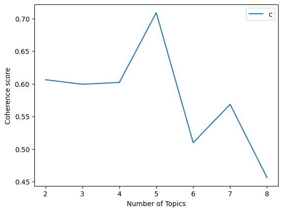

```python
start,stop,step=2,9,1
plot_graph(clean_text,start,stop,step)
```